# tidySDOH Walkthrough: Computing the Yost Index

Author

Rafael Catoia Pulgrossi | [QSU](https://med.stanford.edu/qsu) | [Tae Yoon Lee](https://profiles.stanford.edu/tae-yoon-lee) | [Summer Han](https://med.stanford.edu/summerhanlab.html)

Published

April 13, 2026

## Getting Started with tidySDOH

### Installation

You can install the development version of `tidySDOH` from GitHub:

```r
# install.packages("devtools")
devtools::install_github("HanLabCollaboration/tidySDOH")
```

### Census API Key

To use `tidySDOH`, you’ll need a free Census API key:

```r
# 1. Get a key at: https://api.census.gov/data/key_signup.html
# 2. Install it for use with tidycensus:
tidycensus::census_api_key("YOUR_KEY_HERE", install = TRUE)
```

### Basic Usage

The main function is `computeYostIndex()`:

```r
# Compute Yost Index for California census tracts (2022 ACS)
yost_results <- computeYostIndex(
  geo = "tract",           # Geography: "county", "tract", or "block group"
  year = 2022,             # ACS 5-year survey year
  states = "CA",           # State(s) to analyze
  scope = "state",         # Ranking scope: "national", "state", or "county"
  impute = TRUE,           # Spatially impute missing values
  keep_geometry = TRUE,    # Include spatial geometries for mapping
  return_format = "detailed"  # Return detailed results
)
```

```r
head(yost_results$df_yost)
```

```
# A tibble: 6 × 4
  GEOID       YostImputed YostImputedQuintile annotation
  <chr>             <dbl> <fct>               <chr>
1 06001400100        11.7 5                   Complete data
2 06001400200        11.6 5                   Complete data
3 06001400300        11.4 5                   Complete data
4 06001400400        11.4 5                   Complete data
5 06001400500        10.7 4                   Complete data
6 06001400600        11.2 5                   Complete data
```

### Understanding the Output

When using `return_format = "detailed"`, the function returns a list with:

- `df_yost_raw`: **Baseline** Yost score (no shrinkage, no imputation) — always present for comparison
- `df_yost`: **Requested** Yost score, named dynamically based on the parameters used:
  - `Yost` / `YostQuintile` — when `shrink = FALSE` and `impute = FALSE`
  - `YostImputed` / `YostImputedQuintile` — when `impute = TRUE`
  - `YostShrunk` / `YostShrunkQuintile` — when `shrink = TRUE`
  - `YostShrunkImputed` / `YostShrunkImputedQuintile` — when both are `TRUE`
- `df_raw_values`: Raw ACS values (estimates and margins of error) before any processing
- `df_geometry`: Spatial geometry (if `keep_geometry = TRUE`)
- `df_imputed`: Variable values after imputation
- `df_rank`: Ranked/standardized variables used in factor analysis
- `obj_factor`: Factor analysis object(s) from `psych::fa`

For simpler use cases, set `return_format = "minimal"` to get just the GEOID, Yost score, and quintile.

### Key Parameters

- **`geo`**: Geographic level (`"county"`, `"tract"`, or `"block group"`)
- **`year`**: ACS 5-year survey year (≥ 2011)
- **`states`**: State abbreviations (e.g., `"CA"`, `c("CA", "NY")`, or `"all"`)
- **`scope`**: Comparison scope
  - `"national"`: Rank all geographies against each other (nationwide)
  - `"state"`: Rank within each state separately
  - `"county"`: Rank within each county separately
- **`shrink`**: Whether to apply shrinkage stabilization (see Shrinkage Stabilization below)
- **`impute`**: Whether to perform spatial imputation for missing data (recommended: `TRUE`)
- **`keep_geometry`**: Whether to include spatial geometries for mapping

## Visualizing the Yost Index

### Creating a Map

To create maps, we need to compute the Yost Index with `keep_geometry = TRUE`. We’ll use the results from our earlier computation:

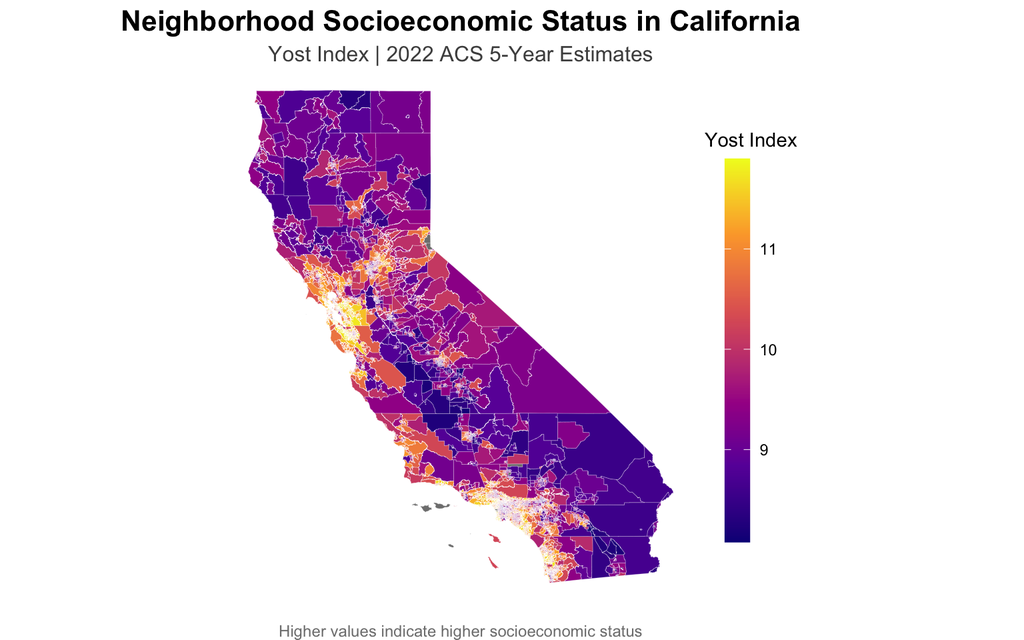

```r
# Join the geometry with the Yost Index data
# We use left_join to preserve all geometries and add Yost scores to each tract
df_ca_plot <- yost_results$df_geometry |>
  dplyr::left_join(yost_results$df_yost, by = "GEOID")

# Create a choropleth map showing the continuous Yost Index
ggplot(df_ca_plot) +
  # geom_sf creates the map; we fill by Yost value and use thin white borders
  geom_sf(aes(fill = YostImputed), color = 'white', size = 0.05) +
  # Use a continuous color scale (viridis plasma) for the Yost Index
  scale_fill_viridis_c(
    option = "plasma",
    name = "Yost Index",
    guide = guide_colorbar(
      barwidth = 1,
      barheight = 15,
      title.position = "top",
      title.hjust = 0.5
    )
  ) +
  # Add informative labels
  labs(
    title = "Neighborhood Socioeconomic Status in California",
    subtitle = "Yost Index | 2022 ACS 5-Year Estimates",
    caption = "Higher values indicate higher socioeconomic status"
  ) +
  # theme_void removes axes and grid for a clean map appearance
  theme_void() +
  theme(
    plot.title = element_text(face = "bold", size = 16, hjust = 0.5),
    plot.subtitle = element_text(size = 12, hjust = 0.5, color = "grey30"),
    plot.caption = element_text(size = 9, hjust = 0.5, color = "grey50", margin = margin(t = 10)),
    legend.position = "right",
    plot.margin = margin(0, 0, 0, 0)
  )
```

### Mapping a Specific County

You can filter to map a specific county or region:

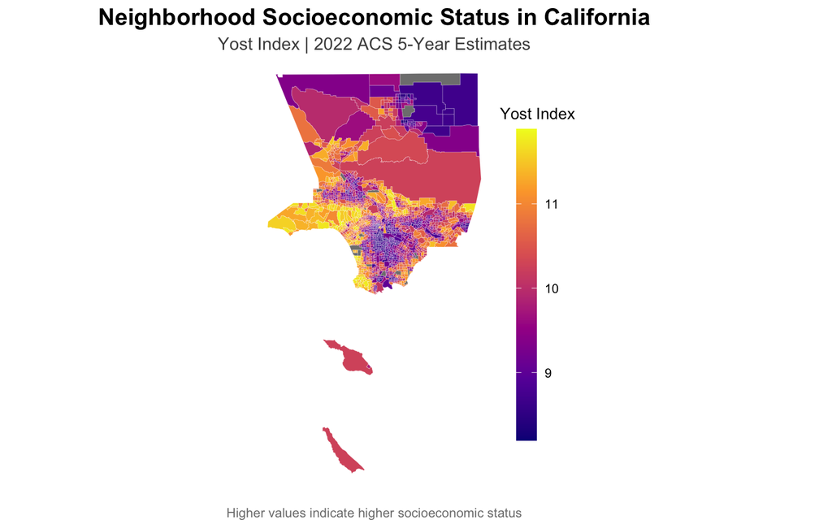

```r
# Filter for Los Angeles County (FIPS code starts with 06037)
df_la_plot <- yost_results$df_geometry |>
  dplyr::left_join(yost_results$df_yost, by = "GEOID") %>%
  filter(grepl("^06037", GEOID))

# Create a choropleth map showing the continuous Yost Index
ggplot(df_la_plot) +
  # geom_sf creates the map; we fill by Yost value and use thin white borders
  geom_sf(aes(fill = YostImputed), color = 'white', size = 0.05) +
  # Use a continuous color scale (viridis plasma) for the Yost Index
  scale_fill_viridis_c(
    option = "plasma",
    name = "Yost Index",
    guide = guide_colorbar(
      barwidth = 1,
      barheight = 15,
      title.position = "top",
      title.hjust = 0.5
    )
  ) +
  # Add informative labels
  labs(
    title = "Neighborhood Socioeconomic Status in California",
    subtitle = "Yost Index | 2022 ACS 5-Year Estimates",
    caption = "Higher values indicate higher socioeconomic status"
  ) +
  # theme_void removes axes and grid for a clean map appearance
  theme_void() +
  theme(
    plot.title = element_text(face = "bold", size = 16, hjust = 0.5),
    plot.subtitle = element_text(size = 12, hjust = 0.5, color = "grey30"),
    plot.caption = element_text(size = 9, hjust = 0.5, color = "grey50", margin = margin(t = 10)),
    legend.position = "right",
    plot.margin = margin(0, 0, 0, 0)
  )
```

## Shrinkage Stabilization

### The Problem: Small-Area Estimation Noise

When working at fine geographic levels — particularly census tracts and block groups — ACS estimates can be highly unreliable. A block group with a small population may have a median household income estimate with a margin of error (MOE) larger than the estimate itself. This sampling noise can distort the Yost Index, making some areas appear extreme simply due to measurement uncertainty rather than true socioeconomic differences.

### The Solution: Borrowing Strength from Parent Geographies

The shrinkage method addresses this by pulling noisy lower-level estimates toward the value of their parent geography. For example, a block group estimate is pulled toward its tract-level value, weighted by how uncertain the block group estimate is relative to how much the block groups within that tract actually vary from one another.

The shrinkage weight is defined as:

$$w = \frac{t^2}{s^2 + t^2}$$

Where:

- $t^2$ = within-parent heterogeneity (how much block groups vary within their tract)
- $s^2 = (\text{MOE} / 1.645)^2$ = sampling variance from the ACS margin of error

When a block group is **reliable** ($s^2$ is small relative to $t^2$), $w \approx 1$ and the estimate is used as-is. When it is **unreliable** ($s^2$ is large), $w \approx 0$ and the block group is pulled strongly toward its parent. Shrinkage is not applied when there is only one unit within a parent geography, or when either variance component is zero.

The supported geographic hierarchies are:

| Lower level | Parent level |
| --- | --- |
| Block group | Tract |
| Tract | County |
| County | State |

### Using Shrinkage

Enable shrinkage with `shrink = TRUE`. The output always includes both `df_yost_raw` (no shrinkage) and `df_yost` (shrunk) so you can compare them directly:

```r
yost_shrunk <- computeYostIndex(
  geo    = "tract",
  year   = 2022,
  states = "CA",
  scope  = "state",
  shrink = TRUE,
  impute = FALSE,
  keep_geometry = FALSE,
  return_format = "detailed"
)
```

```r
# Baseline Yost (no shrinkage)
head(yost_shrunk$df_yost_raw)
```

```
# A tibble: 6 × 4
  GEOID        Yost YostQuintile annotation
  <chr>       <dbl> <fct>        <chr>
1 06001400100  11.7 5            Complete data
2 06001400200  11.6 5            Complete data
3 06001400300  11.4 5            Complete data
4 06001400400  11.4 5            Complete data
5 06001400500  10.7 4            Complete data
6 06001400600  11.2 5            Complete data
```

```r
# Shrunk Yost
head(yost_shrunk$df_yost)
```

```
# A tibble: 6 × 4
  GEOID       YostShrunk YostShrunkQuintile annotation
  <chr>            <dbl> <fct>              <chr>
1 06001400100       11.7 5                  Complete data
2 06001400200       11.6 5                  Complete data
3 06001400300       11.4 5                  Complete data
4 06001400400       11.4 5                  Complete data
5 06001400500       10.7 4                  Complete data
6 06001400600       11.3 5                  Complete data
```

### Comparing Raw vs. Shrunk Estimates

A useful diagnostic is to plot the raw against the shrunk values. Estimates that changed substantially are those where the ACS MOE was large relative to within-parent variability:

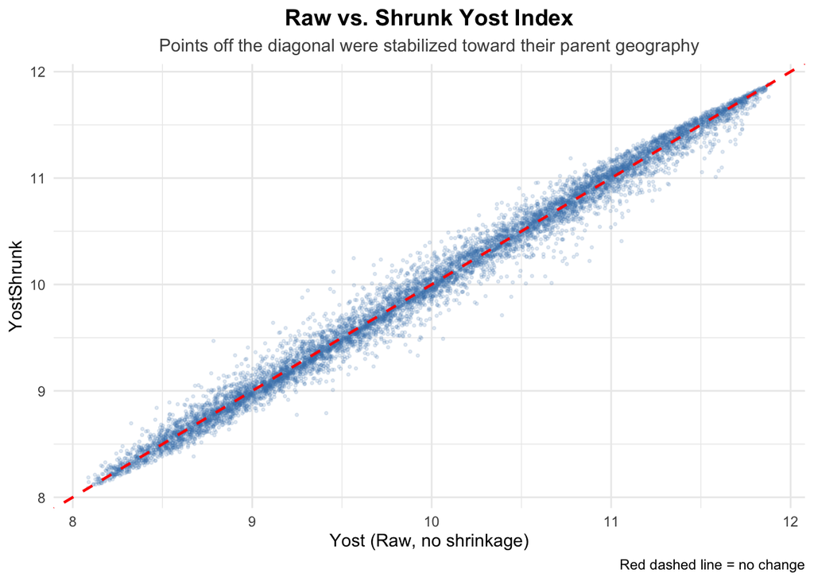

```r
library(dplyr)
library(ggplot2)

# Join raw and shrunk on GEOID
comparison <- yost_shrunk$df_yost_raw |>
  dplyr::rename(Yost_raw = Yost, Quintile_raw = YostQuintile) |>
  dplyr::left_join(
    yost_shrunk$df_yost |>
      dplyr::rename(Yost_shrunk = YostShrunk, Quintile_shrunk = YostShrunkQuintile),
    by = c("GEOID", "annotation")
  )

ggplot(comparison, aes(x = Yost_raw, y = Yost_shrunk)) +
  geom_point(alpha = 0.15, size = 0.6, color = "steelblue") +
  geom_abline(slope = 1, intercept = 0, color = "red", linetype = "dashed", linewidth = 0.8) +
  labs(
    title    = "Raw vs. Shrunk Yost Index",
    subtitle = "Points off the diagonal were stabilized toward their parent geography",
    x        = "Yost (Raw, no shrinkage)",
    y        = "YostShrunk",
    caption  = "Red dashed line = no change"
  ) +
  theme_minimal() +
  theme(
    plot.title    = element_text(face = "bold", size = 14, hjust = 0.5),
    plot.subtitle = element_text(size = 11, hjust = 0.5, color = "grey30")
  )
```

### When Should You Use Shrinkage?

| Situation | Recommendation |
| --- | --- |
| County-level analysis | Generally not needed — estimates are stable |
| Tract-level analysis | Consider using, especially for smaller states or rural areas |
| Block group analysis | **Strongly recommended** — MOEs at this level can be very large |
| Checking reliability | Always compare `df_yost_raw` vs `df_yost` to assess impact |

## Further Reading

For more information on the Yost Index and its applications:

- Yost, K., Perkins, C., Cohen, R., Morris, C., & Wright, W. (2001). Socioeconomic status and breast cancer incidence in California for different race/ethnic groups. *Cancer Causes & Control*, 12(8), 703-711.
- Yang, J., Schupp, C., Harrati, A., Clarke, C., Keegan, T. H., & Gomez, S. L. (2014). Developing an area-based socioeconomic measure from American Community Survey data. *Cancer Prevention Research*, 7(7).

For package documentation and source code:

- GitHub: https://github.com/HanLabCollaboration/tidySDOH
- Issues: https://github.com/HanLabCollaboration/tidySDOH/issues